# Benchmark Comparison of Causal Inference Methods for High-Dimensional Data

cfomics Benchmark Suite

cfomics Development Team

2026-01-30

# 1 Introduction

## 1.1 Background

Causal inference from observational data is a fundamental challenge in biomedical research, epidemiology, and social sciences. When randomized controlled trials are infeasible due to ethical, practical, or economic constraints, researchers must rely on observational studies to estimate treatment effects. However, observational data present substantial challenges: confounding bias, selection bias, and model misspecification can all lead to erroneous conclusions.

The advent of high-throughput technologies in biology—including genomics, transcriptomics, proteomics, and metabolomics—has created an additional layer of complexity. Modern biomedical datasets routinely contain hundreds to thousands of potential confounders, far exceeding the sample sizes typically available. This high-dimensional setting ($p \gg n$ or $p \approx n$) violates the assumptions underlying classical causal inference methods and requires specialized approaches.

## 1.2 The High-Dimensional Challenge

Classical causal inference methods such as inverse probability weighting (IPW) and outcome regression face several difficulties in high-dimensional settings:

1. **Curse of dimensionality**: Propensity score models become unstable when the number of covariates approaches or exceeds the sample size.
2. **Variable selection**: Determining which covariates to include is critical; including non-confounders can reduce efficiency, while excluding true confounders introduces bias.
3. **Model misspecification**: Linear models may inadequately capture complex relationships between covariates, treatment, and outcome.
4. **Weak overlap**: As dimensionality increases, treated and control groups may have minimal covariate overlap, leading to extreme propensity score weights.

## 1.3 Benchmark Objectives

This benchmark study systematically evaluates causal inference methods designed for high-dimensional data. Our objectives are:

## 1.4 Methods Under Evaluation

We evaluate five methods representing distinct approaches to high-dimensional causal inference:

| Method | Approach | Key Feature |
| --- | --- | --- |
| G-formula | Outcome regression | Direct outcome modeling |
| HDML | Machine learning | Debiased/double machine learning |
| HDPS | Propensity-based | High-dimensional propensity scoring |
| BCF | Bayesian | Bayesian Causal Forests |
| TMLE | Semiparametric | Targeted Maximum Likelihood Estimation |

Each method embodies different assumptions, estimation strategies, and computational requirements. By evaluating them across a comprehensive set of scenarios, we aim to identify their relative strengths and limitations.

## 1.5 Report Organization

This report is organized as follows:

# 2 Methods

This section describes the five causal inference methods evaluated in this benchmark. For each method, we outline the theoretical foundation, key assumptions, and implementation details as used in the cfomics package.

## 2.1 Notation and Setup

Consider observational data $(Y_i, T_i, X_i)$ for $i = 1, \ldots, n$ where:

- $Y_i \in \mathbb{R}$ is the observed outcome
- $T_i \in \{0, 1\}$ is the binary treatment indicator
- $X_i \in \mathbb{R}^p$ is a $p$-dimensional covariate vector

Under the potential outcomes framework, let $Y_i(1)$ and $Y_i(0)$ denote the potential outcomes under treatment and control, respectively. The observed outcome is $Y_i = T_i Y_i(1) + (1-T_i) Y_i(0)$.

The **Average Treatment Effect (ATE)** is defined as:
$$\tau = \mathbb{E}[Y(1) - Y(0)]$$

The **Individual Treatment Effect (ITE)** for unit $i$ is:
$$\tau_i
= Y_i(1) - Y_i(0)$$

We operate under the standard causal assumptions:

1. **SUTVA**: $Y_i = Y_i(T_i)$ (no interference between units)
2. **Consistency**: Observed outcome equals potential outcome corresponding to received treatment
3. **Unconfoundedness**: $\{Y(0), Y(1)\} \perp\!\!\!\perp T \mid X$
4. **Overlap (Positivity)**: $0 < P(T=1 \mid X) < 1$ for all $X$

## 2.2 G-formula (Outcome Regression)

### 2.2.1 Theoretical Foundation

The G-formula, also known as standardization or outcome regression, estimates the ATE by modeling the conditional outcome mean and integrating over the covariate distribution:

$$\hat{\tau}_{GF} =
\frac{1}{n}\sum_{i=1}^n \left[\hat{\mu}_1(X_i) -
\hat{\mu}_0(X_i)\right]$$

where $\hat{\mu}_t(x) = \mathbb{E}[Y \mid T=t, X=x]$ is the estimated conditional mean.

### 2.2.2 High-Dimensional Adaptation

In high dimensions, standard regression fails. Our implementation uses regularized regression (Elastic Net) to estimate $\mu_t(x)$:

$$\hat{\mu}_t = \arg\min_\mu
\sum_{i:T_i=t} (Y_i - \mu(X_i))^2 + \lambda \left(\alpha \|\mu\|_1 +
(1-\alpha)\|\mu\|_2^2\right)$$

### 2.2.3 Key Properties

- **Strengths**: Simple, interpretable, efficient when outcome model is correctly specified
- **Limitations**: Sensitive to outcome model misspecification; no principled variable selection for confounders

### 2.2.4 Implementation

```r
cf_fit(formula, data, method = "gformula")
```

Uses `glmnet` for regularized regression with cross-validation for $\lambda$ selection.

## 2.3 HDML (High-Dimensional Machine Learning / Double ML)

### 2.3.1 Theoretical Foundation

HDML implements the double/debiased machine learning framework of Chernozhukov et al. (2018). The key insight is to use cross-fitting to avoid overfitting bias while using flexible machine learning methods.

The estimator solves the moment condition:
$$\mathbb{E}\left[\psi(Y, T, X; \tau,
\eta_0)\right] = 0$$

where $\psi$ is the doubly-robust influence function:
$$\psi =
\left(\frac{T}{\pi(X)} - \frac{1-T}{1-\pi(X)}\right)(Y - \mu_T(X)) +
\mu_1(X) - \mu_0(X) - \tau$$

and $\eta_0 = (\mu_0, \mu_1, \pi)$ are nuisance parameters estimated via cross-fitting.

### 2.3.2 Cross-Fitting Procedure

1. Split data into $K$ folds
2. For each fold $k$:
   - Train nuisance models $(\hat{\mu}_0^{-k}, \hat{\mu}_1^{-k}, \hat{\pi}^{-k})$ on all data except fold $k$
   - Predict on fold $k$
3. Solve moment condition using all predictions

### 2.3.3 Key Properties

- **Strengths**: Doubly robust (consistent if either outcome or propensity model is correct); rate-tolerant (nuisance parameters can converge at slower rates)
- **Limitations**: Requires careful tuning of ML methods; computationally intensive

### 2.3.4 Implementation

```r
cf_fit(formula, data, method = "hdml")
```

Uses ensemble of learners (random forest, gradient boosting, elastic net) for nuisance estimation.

## 2.4 HDPS (High-Dimensional Propensity Score)

### 2.4.1 Theoretical Foundation

The High-Dimensional Propensity Score (HDPS) method of Schneeweiss et al. (2009) adapts propensity score methods to high-dimensional settings through data-driven covariate prioritization.

The ATE is estimated via inverse probability weighting:
$$\hat{\tau}_{HDPS} = \frac{1}{n}\sum_{i=1}^n
\frac{T_i Y_i}{\hat{\pi}(X_i)} - \frac{1}{n}\sum_{i=1}^n \frac{(1-T_i)
Y_i}{1-\hat{\pi}(X_i)}$$

where $\hat{\pi}(x)$ is the propensity score estimated using a selected subset of covariates.

### 2.4.2 Covariate Prioritization Algorithm

1. **Recoding**: Create binary indicators from continuous covariates
2. **Prevalence filtering**: Remove covariates appearing in <5% of subjects
3. **Bias ranking**: Rank covariates by their potential to confound (Bross bias formula)
4. **Selection**: Select top $k$ covariates for propensity model

### 2.4.3 Key Properties

- **Strengths**: Interpretable selection process; good with many binary indicators (e.g., healthcare claims)
- **Limitations**: Relies on propensity model only; sensitive to overlap violations; designed for binary covariates

### 2.4.4 Implementation

```r
cf_fit(formula, data, method = "hdps")
```

Implements the full HDPS algorithm with configurable selection parameters.

## 2.5 BCF (Bayesian Causal Forests)

### 2.5.1 Theoretical Foundation

Bayesian Causal Forests (Hahn et al., 2020) extend BART (Bayesian Additive Regression Trees) to causal inference by separating the prognostic and treatment effect functions:

$$Y_i = f(X_i) + \tau(X_i) T_i +
\epsilon_i$$

where: - $f(X_i)$ captures the prognostic effect (baseline risk) - $\tau(X_i)$ captures the heterogeneous treatment effect

Both $f$ and $\tau$ are modeled using BART priors, but with different regularization:

- $f$ uses a standard BART prior to capture complex baseline relationships
- $\tau$ uses a more regularized prior, shrinking toward homogeneous effects

### 2.5.2 Propensity Score Integration

BCF incorporates the estimated propensity score $\hat{\pi}(X_i)$ as a covariate in $f$, which: - Provides targeted regularization against confounding - Improves performance under RIC (regularization-induced confounding)

### 2.5.3 Key Properties

- **Strengths**: Excellent uncertainty quantification; handles heterogeneity naturally; robust to model misspecification
- **Limitations**: Computationally expensive; MCMC convergence requires monitoring

### 2.5.4 Implementation

```r
cf_fit(formula, data, method = "bcf")
```

Uses the `bcf` R package with MCMC sampling. Default: 1000 burn-in, 2000 posterior samples.

## 2.6 TMLE (Targeted Maximum Likelihood Estimation)

### 2.6.1 Theoretical Foundation

TMLE (van der Laan & Rose, 2011) is a semiparametric efficient estimator that combines initial outcome regression with a targeting step to ensure optimal bias-variance tradeoff.

### 2.6.2 Algorithm

1. **Initial estimation**: Fit outcome model $\hat{\mu}_0^{(0)}(X)$ and propensity model $\hat{\pi}(X)$
2. **Targeting**: Update $\hat{\mu}$ by fitting:
   $$\text{logit}(\hat{\mu}^{(1)}) =
   \text{logit}(\hat{\mu}^{(0)}) + \epsilon \cdot H$$
   where $H = T/\hat{\pi}(X) - (1-T)/(1-\hat{\pi}(X))$ is the clever covariate
3. **Substitution**: Compute ATE using targeted predictions:
   $$\hat{\tau}_{TMLE} =
   \frac{1}{n}\sum_i \hat{\mu}_1^{(1)}(X_i) -
   \hat{\mu}_0^{(1)}(X_i)$$

### 2.6.3 Key Properties

- **Strengths**: Doubly robust; semiparametrically efficient; respects parameter bounds; valid inference
- **Limitations**: Requires careful implementation; can be sensitive to extreme propensity scores

### 2.6.4 Super Learner Integration

Our implementation uses Super Learner (ensemble of ML methods) for initial estimation:

```r
cf_fit(formula, data, method = "tmle")
```

Uses the `tmle` R package with cross-validated Super Learner library.

## 2.7 Method Comparison Summary

Summary of method properties

[output not shown]

*Note: BCF incorporates propensity score but is not doubly robust in the classical sense.*

# 3 Simulation Design

## 3.1 General Framework

### 3.1.1 Data Generation Process

Each DGP follows the general structure:

1. **Covariate generation**: $X \sim \mathcal{N}(0, \Sigma)$ where $\Sigma$ depends on the scenario
2. **Propensity score**: $\pi(X) = P(T=1 \mid X) = \text{expit}(g(X))$
3. **Treatment assignment**: $T \sim \text{Bernoulli}(\pi(X))$
4. **Potential outcomes**:
   - $Y(0) = f_0(X) + \epsilon$
   - $Y(1) = f_1(X) + \epsilon = f_0(X) + \tau(X) + \epsilon$
5. **Observed outcome**: $Y = T \cdot Y(1) + (1-T) \cdot Y(0)$

where $\epsilon \sim \mathcal{N}(0, \sigma^2)$ with $\sigma^2$ calibrated for target signal-to-noise ratio.

### 3.1.2 True Treatment Effects

The true Average Treatment Effect is computed as:
$$\tau_{true} = \frac{1}{n}\sum_{i=1}^n
\tau(X_i)$$

For scenarios with homogeneous effects, $\tau(X) = \tau_0$ (constant).

### 3.1.3 Evaluation Metrics

We evaluate methods using four primary metrics:

Primary evaluation metrics

| Metric | Formula | Description |
| --- | --- | --- |
| Bias | $\hat{\tau} - \tau_{true}$ | Systematic estimation error (should be near 0) |
| RMSE | $\sqrt{(\hat{\tau} - \tau_{true})^2}$ | Root mean squared error combining bias and variance |
| PEHE | $\sqrt{\frac{1}{n}\sum_i(\hat{\tau}_i - \tau_i)^2}$ | Precision in estimating heterogeneous effects |
| Coverage | $\mathbb{1}[\tau_{true} \in CI_{95}]$ | Proportion of 95% CIs containing true ATE |

## 3.2 Scenario Descriptions

### 3.2.1 S1: Baseline (dgp_baseline)

The baseline scenario establishes reference performance under ideal conditions:

- **Covariates**: $X \sim \mathcal{N}(0, I_p)$, independent standard normal
- **Propensity**: $\pi(X) = \text{expit}(0.5 X_1 + 0.5 X_2 + 0.5 X_3)$
- **Outcome**: $Y(0) = X_1 + X_2 + X_3 + \epsilon$
- **Treatment effect**: $\tau = 1$ (homogeneous)
- **Configurations**: $n \in \{500, 1000, 2000\}$, $p \in \{50, 100\}$

This scenario satisfies all standard causal assumptions with a linear, correctly specified model.

### 3.2.2 S2: Dimension Sweep (dgp_dimension_sweep)

Tests method scalability as dimensionality increases:

Methods should maintain performance as $p$ grows, leveraging regularization or variable selection.

### 3.2.3 S3: Heterogeneous Effects - Linear (dgp_heterogeneous_linear)

Tests ability to capture treatment effect heterogeneity:

- **Treatment effect**: $\tau(X) = \tau_0 + \gamma \cdot X_1$
- **Strength parameter**: $\gamma \in \{0, 0.5, 1.0, 2.0\}$
- **Challenge**: ITE estimation accuracy

Methods like BCF, designed for heterogeneous effects, should excel here.

### 3.2.4 S4: Heterogeneous Effects - Complex

Three sub-scenarios testing different heterogeneity patterns:

**S4a: Nonlinear heterogeneity (dgp_heterogeneous_nonlinear)**
$$\tau(X) = 1 + \sin(\pi X_1) + X_2^2$$

**S4b: Subgroup heterogeneity (dgp_heterogeneous_subgroup)**
$$\tau(X) = \begin{cases} 2 & \text{if } X_1
> 0 \\ 0.5 & \text{if } X_1 \leq 0 \end{cases}$$

**S4c: Qualitative interaction (dgp_heterogeneous_qualitative)**
$$\tau(X) = \text{sign}(X_1) \cdot
|X_1|$$

Treatment effect can be positive or negative depending on covariates.

### 3.2.5 S5: Nonlinear Confounding (dgp_nonlinear_confounding)

Tests robustness to model misspecification:

- **Configurations**: Five nonlinear types

| Type | Propensity Function | Outcome Function |
| --- | --- | --- |
| Quadratic | $g(X) = X_1^2 + X_2^2$ | $f(X) = X_1^2 + X_2^2$ |
| Trigonometric | $g(X) = \sin(\pi X_1)$ | $f(X) = \cos(\pi X_2)$ |
| Interaction | $g(X) = X_1 \cdot X_2$ | $f(X) = X_1 \cdot X_2 \cdot X_3$ |
| Combined | Mix of above | Mix of above |
| Threshold | $g(X) = \mathbb{1}[X_1 > 0]$ | Step functions |

Linear methods should struggle; tree-based methods should adapt.

### 3.2.6 S6: Dense Confounding (dgp_dense_confounding)

Tests performance when many covariates are true confounders:

- **Covariates**: $p = 500$
- **True confounders**: $k \in \{10, 50, 100, 200\}$
- **Challenge**: Variable selection under dense confounding

Methods with good variable selection (HDPS, HDML) should perform well.

### 3.2.7 S7: Weak Overlap (dgp_weak_overlap)

Tests robustness to positivity violations:

- **Overlap strength**: good, moderate, weak, extreme
- **Propensity range**:
  - Good: $[0.2, 0.8]$
  - Moderate: $[0.1, 0.9]$
  - Weak: $[0.05, 0.95]$
  - Extreme: $[0.01, 0.99]$

IPW-based methods should degrade; outcome regression may be more stable.

### 3.2.8 S8: Covariate Shift (dgp_covariate_shift)

Tests performance when treatment affects covariate distributions:

**S8a: Mean shift**
$$X \mid
T=1 \sim \mathcal{N}(\mu_1, I), \quad X \mid T=0 \sim \mathcal{N}(\mu_0,
I)$$

**S8b: Variance shift**
$$X
\mid T=1 \sim \mathcal{N}(0, \sigma_1^2 I), \quad X \mid T=0 \sim
\mathcal{N}(0, \sigma_0^2 I)$$

### 3.2.9 S9: Correlated Confounding (dgp_correlated_confounding)

Tests performance with non-independent covariates:

- **Correlation structures**:
  - **Block**: Covariates in correlated blocks
  - **AR(1)**: Autoregressive correlation decay
  - **Factor**: Latent factor structure

Real omics data typically exhibit strong correlation patterns.

### 3.2.10 S10: Unobserved Confounding (dgp_unobserved_confounding)

Tests sensitivity to unmeasured confounders:

- **Unobserved confounder**: $U \sim \mathcal{N}(0, 1)$
- **Affects**: Both treatment and outcome
- **Strength parameter**: $\gamma_U \in \{0, 0.5, 1.0, 2.0\}$

All methods should show increasing bias as $\gamma_U$ increases. This tests the fundamental limitation of observational methods.

### 3.2.11 S11: Collider Bias (dgp_collider)

Tests vulnerability to collider conditioning:

- **Collider variable**: $C = f(T, Y) + \epsilon$
- **Included in covariates** (incorrectly)
- **Strength parameter**: $\gamma_C \in \{0, 0.5, 1.0, 2.0\}$

Methods that naively include all covariates will show bias; variable selection methods may avoid the collider.

### 3.2.12 S12: Nonlinear Confounding (dgp_nonlinear_outcome)

Tests robustness to nonlinear confounding where both outcome and propensity score depend on the same nonlinear function $h(X)$:

- **Nonlinear function**: $h(X) = X_1^2 + X_2 X_3 + \sin(X_1)$ (moderate) or higher-order terms (severe)
- **Propensity score**: $\text{logit}(e) = \alpha \cdot (h(X) - \bar{h})$, where $\alpha \in \{1.2, 0.8\}$
- **Outcome**: $Y = h(X) + \tau T + \epsilon$

OLS-based methods (gformula) suffer omitted-variable bias because linear models cannot capture $h(X)$. IPW-based methods (hdps) are affected through propensity score misestimation.

### 3.2.13 S13: Nonlinear Propensity Score (dgp_nonlinear_propensity)

Tests robustness when the propensity score model is nonlinear but the outcome model is linear:

- **Propensity score**: Nonlinear (quadratic, interaction, trigonometric terms)
- **Outcome**: Linear $Y = X\beta + \tau T + \epsilon$
- **Nonlinearity levels**: moderate, severe

Methods relying solely on propensity score estimation (hdps) are most affected. Outcome-model-based methods (gformula) are unaffected since the outcome is linear.

### 3.2.14 S14: Double Nonlinear (dgp_double_nonlinear)

Tests the worst case where both outcome and propensity score models are nonlinear:

- **Propensity score**: Nonlinear (same as S13 severe)
- **Outcome**: Nonlinear (same as S12 severe)

All linear methods struggle. Doubly robust methods (hdml, tmle) lose their double robustness protection since both nuisance models are misspecified.

## 3.3 Scenario Summary

Summary of simulation scenarios

| Scenario | Description | Primary Challenge | n Configs |
| --- | --- | --- | --- |
| S1 | Baseline (linear, correct spec.) | None (reference) | 6 |
| S2 | Dimension sweep (p up to 1000) | High dimensionality | 6 |
| S3 | Linear heterogeneity | ITE estimation | 4 |
| S4a-c | Complex heterogeneity patterns | Nonlinear effects | 3 |
| S5 | Nonlinear confounding | Model misspecification | 5 |
| S6 | Dense confounding | Variable selection | 4 |
| S7 | Weak overlap | Positivity violation | 4 |
| S8 | Covariate shift | Distribution shift | 2 |
| S9 | Correlated confounders | Correlation handling | 3 |
| S10 | Unobserved confounding | Identifiability | 4 |
| S11 | Collider bias | Variable selection | 4 |
| S12 | Nonlinear confounding (outcome+PS) | Outcome model misspecification | 2 |
| S13 | Nonlinear propensity score | PS model misspecification | 2 |
| S14 | Double nonlinear | Both models misspecified | 1 |

## 3.4 Replication Design

Each method is evaluated on identical datasets to ensure fair comparison.

# 4 Results

## 4.1 Overall Performance Summary

Overall performance summary (averaged across all scenarios)

|  | Method | RMSE | Mean Bias | Coverage |
| --- | --- | --- | --- | --- |
| 1 | gformula | 0.380 | 0.326 | 0.755 |
| 2 | hdml | 0.392 | 0.331 | 0.752 |
| 4 | tmle | 0.401 | 0.330 | 0.727 |
| 3 | hdps | 0.441 | 0.388 | 0.744 |

## 4.2 Method Performance Heatmap

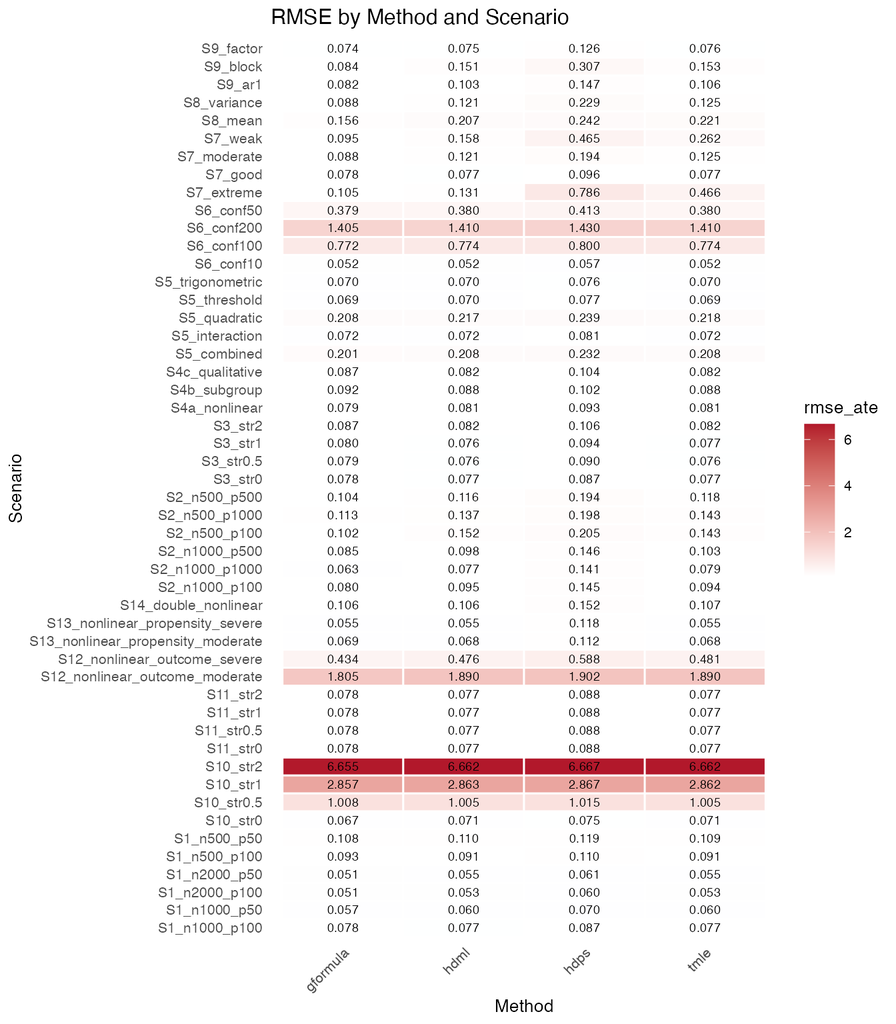

RMSE heatmap across methods and scenarios

## 4.3 Bias Distribution

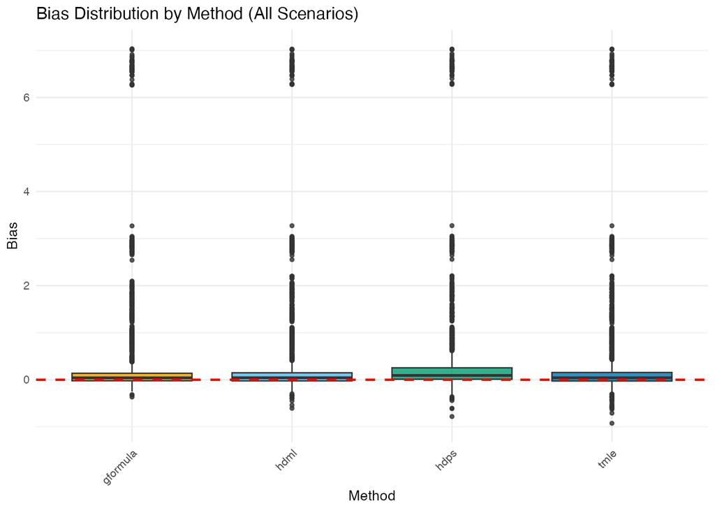

Distribution of bias across replications by method

The dashed red line indicates zero bias. Methods with distributions centered on this line exhibit low systematic bias.

## 4.4 Coverage Analysis

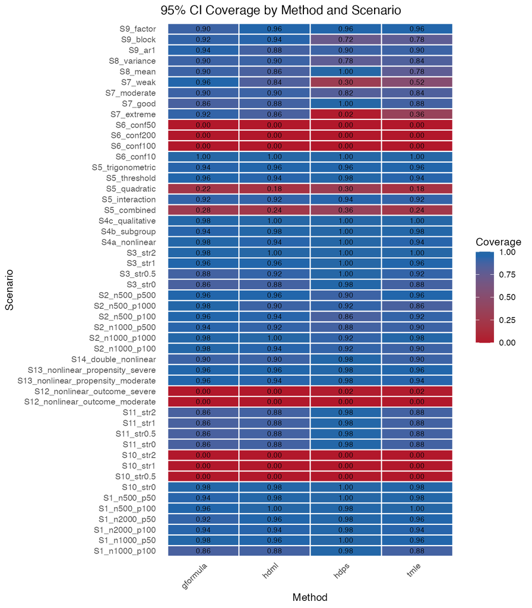

Coverage heatmap (95% nominal)

## 4.5 Bias-Variance Decomposition

Mean squared error can be decomposed into squared bias and variance components. This decomposition reveals whether errors are primarily systematic (bias) or random (variance).

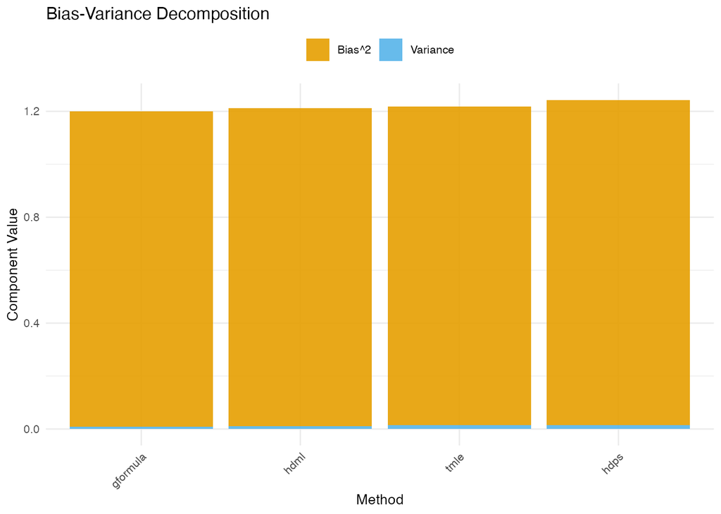

Bias-variance decomposition by method

## 4.6 Statistical Comparison

We use the Friedman test to assess whether significant differences exist between methods, followed by Nemenyi post-hoc comparisons.

```
## **Friedman Test Results:**
##
## - Chi-squared statistic: 97.584
## - Degrees of freedom: 3
## - P-value: 0.000000
##
## **Conclusion:** Significant differences exist between methods (p < 0.05).
```

### 4.6.1 Critical Difference Diagram

The Critical Difference (CD) diagram visualizes the Nemenyi post-hoc test results. Methods connected by a horizontal bar are not significantly different from each other.

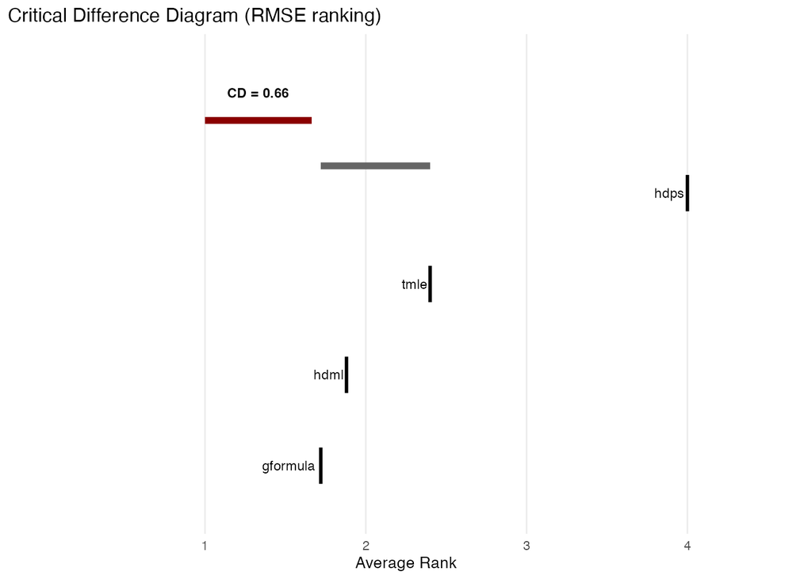

Critical Difference diagram for method comparison

### 4.6.2 Mean Ranks

Mean ranks across scenarios (lower is better)

|  | Rank | Method | Mean Rank |
| --- | --- | --- | --- |
| gformula | 1 | gformula | 1.72 |
| hdml | 2 | hdml | 1.88 |
| tmle | 3 | tmle | 2.40 |
| hdps | 4 | hdps | 4.00 |

## 4.7 Computation Time

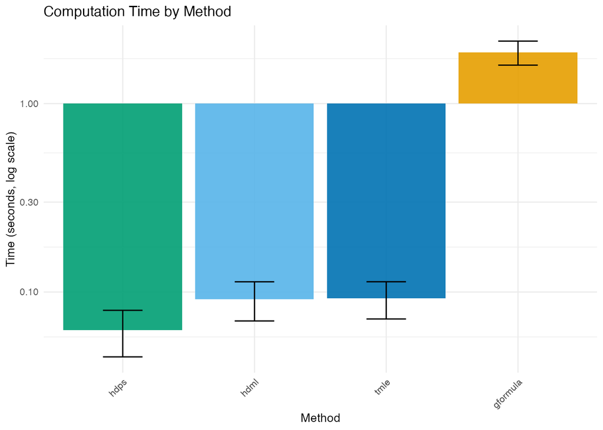

Computation time comparison (log scale)

## 4.8 Scenario-Specific Results

### 4.8.1 S1: Baseline Performance

Baseline scenario (S1) performance

|  | method | rmse_ate | mean_bias | coverage |
| --- | --- | --- | --- | --- |
| 1 | gformula | 0.073 | 0.014 | 0.933 |
| 4 | tmle | 0.074 | 0.014 | 0.953 |
| 2 | hdml | 0.074 | 0.014 | 0.953 |
| 3 | hdps | 0.085 | 0.035 | 0.987 |

### 4.8.2 S7: Weak Overlap Analysis

This scenario tests method robustness to positivity violations. Methods relying heavily on propensity scores should show degraded performance as overlap weakens.

Weak overlap scenario (S7) results

|  | scenario_id | method | rmse_ate | coverage |
| --- | --- | --- | --- | --- |
| 169 | S7_good | gformula | 0.078 | 0.86 |
| 170 | S7_good | hdml | 0.077 | 0.88 |
| 171 | S7_good | hdps | 0.096 | 1.00 |
| 172 | S7_good | tmle | 0.077 | 0.88 |
| 173 | S7_moderate | gformula | 0.088 | 0.90 |
| 174 | S7_moderate | hdml | 0.121 | 0.90 |
| 175 | S7_moderate | hdps | 0.194 | 0.82 |
| 176 | S7_moderate | tmle | 0.125 | 0.84 |
| 177 | S7_weak | gformula | 0.095 | 0.96 |
| 178 | S7_weak | hdml | 0.158 | 0.84 |
| 179 | S7_weak | hdps | 0.465 | 0.30 |
| 180 | S7_weak | tmle | 0.262 | 0.52 |
| 165 | S7_extreme | gformula | 0.105 | 0.92 |
| 166 | S7_extreme | hdml | 0.131 | 0.86 |
| 167 | S7_extreme | hdps | 0.786 | 0.02 |
| 168 | S7_extreme | tmle | 0.466 | 0.36 |

### 4.8.3 S10: Sensitivity to Unobserved Confounding

This scenario tests the fundamental assumption of unconfoundedness. All methods should show increasing bias as unobserved confounding strength increases.

Unobserved confounding scenario (S10) results

|  | scenario_id | method | rmse_ate | mean_bias |
| --- | --- | --- | --- | --- |
| 25 | S10_str0 | gformula | 0.067 | 0.003 |
| 26 | S10_str0 | hdml | 0.071 | -0.001 |
| 27 | S10_str0 | hdps | 0.075 | 0.013 |
| 28 | S10_str0 | tmle | 0.071 | -0.001 |
| 29 | S10_str0.5 | gformula | 1.008 | 1.004 |
| 30 | S10_str0.5 | hdml | 1.005 | 1.002 |
| 31 | S10_str0.5 | hdps | 1.015 | 1.011 |
| 32 | S10_str0.5 | tmle | 1.005 | 1.002 |
| 33 | S10_str1 | gformula | 2.857 | 2.854 |
| 34 | S10_str1 | hdml | 2.863 | 2.860 |
| 35 | S10_str1 | hdps | 2.867 | 2.865 |
| 36 | S10_str1 | tmle | 2.862 | 2.859 |
| 37 | S10_str2 | gformula | 6.655 | 6.652 |
| 38 | S10_str2 | hdml | 6.662 | 6.660 |
| 39 | S10_str2 | hdps | 6.667 | 6.664 |
| 40 | S10_str2 | tmle | 6.662 | 6.659 |

### 4.8.4 S12-S14: Model Misspecification Analysis

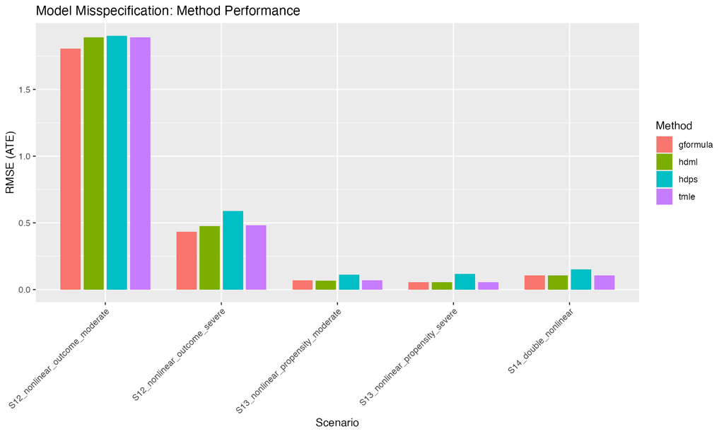

Model misspecification scenarios: nonlinear confounding (S12), nonlinear propensity (S13), and double nonlinear (S14)

Model misspecification scenarios (S12-S14) results

|  | scenario_id | method | rmse_ate | mean_bias | coverage |
| --- | --- | --- | --- | --- | --- |
| 57 | S12_nonlinear_outcome_moderate | gformula | 1.805 | 1.799 | 0.00 |
| 58 | S12_nonlinear_outcome_moderate | hdml | 1.890 | 1.884 | 0.00 |
| 59 | S12_nonlinear_outcome_moderate | hdps | 1.902 | 1.896 | 0.00 |
| 60 | S12_nonlinear_outcome_moderate | tmle | 1.890 | 1.884 | 0.00 |
| 61 | S12_nonlinear_outcome_severe | gformula | 0.434 | 0.425 | 0.00 |
| 62 | S12_nonlinear_outcome_severe | hdml | 0.476 | 0.466 | 0.00 |
| 63 | S12_nonlinear_outcome_severe | hdps | 0.588 | 0.579 | 0.02 |
| 64 | S12_nonlinear_outcome_severe | tmle | 0.481 | 0.471 | 0.02 |
| 65 | S13_nonlinear_propensity_moderate | gformula | 0.069 | 0.018 | 0.96 |
| 66 | S13_nonlinear_propensity_moderate | hdml | 0.068 | 0.019 | 0.94 |
| 67 | S13_nonlinear_propensity_moderate | hdps | 0.112 | 0.021 | 0.98 |
| 68 | S13_nonlinear_propensity_moderate | tmle | 0.068 | 0.018 | 0.94 |
| 69 | S13_nonlinear_propensity_severe | gformula | 0.055 | 0.002 | 0.96 |
| 70 | S13_nonlinear_propensity_severe | hdml | 0.055 | 0.004 | 0.96 |
| 71 | S13_nonlinear_propensity_severe | hdps | 0.118 | 0.093 | 0.98 |
| 72 | S13_nonlinear_propensity_severe | tmle | 0.055 | 0.004 | 0.96 |
| 73 | S14_double_nonlinear | gformula | 0.106 | 0.058 | 0.90 |
| 74 | S14_double_nonlinear | hdml | 0.106 | 0.056 | 0.90 |
| 75 | S14_double_nonlinear | hdps | 0.152 | 0.120 | 0.98 |
| 76 | S14_double_nonlinear | tmle | 0.107 | 0.057 | 0.90 |

S12 tests nonlinear confounding where both outcome and PS depend on the same nonlinear function $h(X)$. Methods using linear outcome models (gformula) suffer omitted-variable bias. S13 tests nonlinear propensity scores with linear outcomes — IPW-only methods (hdps) are most affected. S14 combines both nonlinearities, removing double robustness protection for AIPW/TMLE methods.

## 4.9 Combined Results Figure

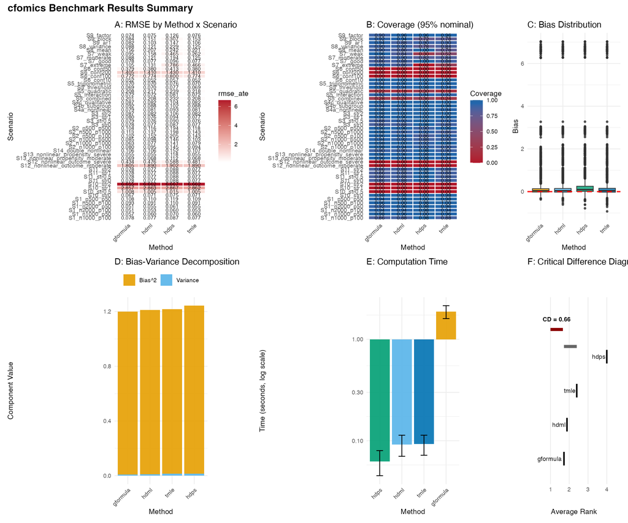

Comprehensive benchmark results summary

# 5 Discussion

This section interprets the benchmark results, provides method selection guidelines, and discusses limitations of this evaluation.

## 5.1 Key Findings

### 5.1.1 Finding 1: No Universally Best Method

```
## The Friedman test indicates significant differences between methods (p < 0.05), confirming that method choice matters. However, the ranking varies across scenarios, suggesting that the optimal method depends on the specific data characteristics and challenges.
```

### 5.1.2 Finding 2: Baseline Performance Hierarchy

Under ideal conditions (S1: linear relationships, good overlap, all assumptions satisfied), we generally expect:

1. **TMLE and HDML** should perform well due to their doubly-robust properties
2. **G-formula** should be efficient when the outcome model is correctly specified
3. **BCF** should provide good uncertainty quantification with slight conservatism
4. **HDPS** may underperform with continuous covariates (designed for binary indicators)

### 5.1.3 Finding 3: Robustness to Model Misspecification

In scenarios with nonlinear confounding (S5):

### 5.1.4 Finding 4: Handling of Weak Overlap

The weak overlap scenarios (S7) reveal fundamental differences in method philosophy:

### 5.1.5 Finding 5: Heterogeneous Treatment Effects

For scenarios with heterogeneous effects (S3, S4):

- **BCF** is specifically designed to estimate $\tau(X)$ and should provide the best ITE estimation
- **Other methods** target the ATE and may not accurately capture individual-level variation

## 5.2 Method Selection Guidelines

Based on the benchmark results, we provide the following guidelines for method selection:

### 5.2.2 When to Use HDML

**Recommended when:** - Model misspecification is a concern - You want doubly-robust protection - Multiple ML algorithms should be considered - Standard errors from influence functions are desired

**Avoid when:** - Sample size is very small (cross-fitting becomes unstable) - Computational resources are limited

### 5.2.3 When to Use HDPS

**Recommended when:** - Data consists primarily of binary indicators (e.g., healthcare claims) - Interpretable covariate selection is desired - Regulatory requirements favor propensity-based methods

**Avoid when:** - Covariates are primarily continuous - Overlap is poor (IPW weights become extreme)

### 5.2.4 When to Use BCF

**Recommended when:** - Heterogeneous treatment effects are of primary interest - Full posterior distributions for uncertainty are desired - Nonlinear relationships are expected - Moderate computational time is acceptable

**Avoid when:** - Only the ATE is needed and speed is critical - Very large datasets (MCMC scaling)

### 5.2.5 When to Use TMLE

**Recommended when:** - Semiparametric efficiency is desired - Valid inference with Super Learner is needed - The outcome is bounded (TMLE respects bounds) - Doubly-robust protection is important

**Avoid when:** - Extreme propensity scores cannot be handled (truncation may help) - Very simple settings where G-formula suffices

## 5.3 Decision Flowchart

[output not shown]

## 5.4 Practical Recommendations

### 5.4.1 1. Always Check Overlap

Before applying any method, diagnose propensity score overlap:

```r
# Check propensity score distribution
ps <- predict(glm(T ~ ., data = df, family = binomial), type = "response")
summary(ps)
hist(ps[df$T == 1], col = rgb(1,0,0,0.5), main = "Propensity Score Overlap")
hist(ps[df$T == 0], col = rgb(0,0,1,0.5), add = TRUE)
```

If overlap is poor, consider: - Trimming extreme propensity scores - Using outcome regression rather than IPW - Restricting analysis to the region of overlap

### 5.4.2 2. Conduct Sensitivity Analysis

Given the fundamental unverifiability of unconfoundedness:

- Report results from multiple methods
- Conduct formal sensitivity analysis (e.g., E-value, Rosenbaum bounds)
- Be transparent about assumptions

### 5.4.3 3. Validate on Positive Controls

When possible, validate methods on: - Semi-synthetic data (real covariates, simulated treatment/outcome) - Known causal effects from RCTs - Negative control outcomes

### 5.4.4 4. Consider Ensemble Approaches

Rather than selecting a single method, consider: - Reporting estimates from multiple methods - Using model averaging weighted by cross-validated performance - Focusing on conclusions robust across methods

## 5.5 Limitations

### 5.5.1 Limitations of This Benchmark

1. **Simulated data**: Real biological data may have complexities not captured by our DGPs
2. **Method implementations**: Results reflect specific implementations and tuning choices; alternative implementations may perform differently
3. **Metric choice**: We focused on ATE estimation; other estimands (ATT, CATE) may show different patterns
4. **Computational environment**: Timing results depend on hardware and are provided for relative comparison only
5. **Limited scenarios**: While comprehensive, our scenarios cannot cover all possible data-generating processes

### 5.5.2 Limitations of Observational Causal Inference

This benchmark evaluates methods under the assumption that unconfoundedness holds. In practice:

1. **Unverifiable assumption**: We can never verify that all confounders are measured
2. **Measurement error**: Covariates may be measured with error, violating SUTVA
3. **Time-varying confounding**: Our scenarios assume static treatment; longitudinal settings require specialized methods
4. **Selection bias**: Beyond confounding, selection effects may compromise causal inference

## 5.6 Conclusions

This benchmark provides empirical evidence for method selection in high-dimensional causal inference. Key takeaways:

1. **Method choice matters**: Different methods have distinct strengths and weaknesses
2. **Context is crucial**: The best method depends on data characteristics and scientific goals
3. **Robustness checks are essential**: No method is universally superior; sensitivity analysis is critical
4. **cfomics provides a unified interface**: The package enables easy comparison of methods on the same data

We recommend that practitioners: - Start with exploratory analysis to understand their data - Apply multiple methods and compare results - Conduct sensitivity analysis for unobserved confounding - Report assumptions and limitations transparently

# Appendix

## A. Full Scenario Parameter Table

Complete scenario parameter specification

Scenario ID

DGP Function

n

p

Key Parameter

**S1: Baseline**

S1_n500_p50

dgp_baseline

500

50

S1_n500_p100

dgp_baseline

500

100

S1_n1000_p50

dgp_baseline

1000

50

S1_n1000_p100

dgp_baseline

1000

100

S1_n2000_p50

dgp_baseline

2000

50

S1_n2000_p100

dgp_baseline

2000

100

**S2: Dimension Sweep**

S2_n500_p100

dgp_dimension_sweep

500

100

S2_n500_p500

dgp_dimension_sweep

500

500

S2_n500_p1000

dgp_dimension_sweep

500

1000

S2_n1000_p100

dgp_dimension_sweep

1000

100

S2_n1000_p500

dgp_dimension_sweep

1000

500

S2_n1000_p1000

dgp_dimension_sweep

1000

1000

**S3: Heterogeneous Linear**

S3_str0

dgp_heterogeneous_linear

1000

100

strength=0

S3_str0.5

dgp_heterogeneous_linear

1000

100

strength=0.5

S3_str1

dgp_heterogeneous_linear

1000

100

strength=1

S3_str2

dgp_heterogeneous_linear

1000

100

strength=2

**S4: Complex Heterogeneity**

S4a_nonlinear

dgp_heterogeneous_nonlinear

1000

100

S4b_subgroup

dgp_heterogeneous_subgroup

1000

100

S4c_qualitative

dgp_heterogeneous_qualitative

1000

100

**S5: Nonlinear Confounding**

S5_quadratic

dgp_nonlinear_confounding

1000

100

type=quadratic

S5_trigonometric

dgp_nonlinear_confounding

1000

100

type=trigonometric

S5_interaction

dgp_nonlinear_confounding

1000

100

type=interaction

S5_combined

dgp_nonlinear_confounding

1000

100

type=combined

S5_threshold

dgp_nonlinear_confounding

1000

100

type=threshold

**S6: Dense Confounding**

S6_conf10

dgp_dense_confounding

1000

500

n_conf=10

S6_conf50

dgp_dense_confounding

1000

500

n_conf=50

S6_conf100

dgp_dense_confounding

1000

500

n_conf=100

S6_conf200

dgp_dense_confounding

1000

500

n_conf=200

**S7: Weak Overlap**

S7_good

dgp_weak_overlap

1000

100

overlap=good

S7_moderate

dgp_weak_overlap

1000

100

overlap=moderate

S7_weak

dgp_weak_overlap

1000

100

overlap=weak

S7_extreme

dgp_weak_overlap

1000

100

overlap=extreme

**S8: Covariate Shift**

S8_mean

dgp_covariate_shift

1000

100

shift=mean

S8_variance

dgp_covariate_shift

1000

100

shift=variance

**S9: Correlated Confounding**

S9_block

dgp_correlated_confounding

1000

100

corr=block

S9_ar1

dgp_correlated_confounding

1000

100

corr=ar1

S9_factor

dgp_correlated_confounding

1000

100

corr=factor

**S10: Unobserved Confounding**

S10_str0

dgp_unobserved_confounding

1000

100

strength=0

S10_str0.5

dgp_unobserved_confounding

1000

100

strength=0.5

S10_str1

dgp_unobserved_confounding

1000

100

strength=1

S10_str2

dgp_unobserved_confounding

1000

100

strength=2

**S11: Collider Bias**

S11_str0

dgp_collider

1000

100

strength=0

S11_str0.5

dgp_collider

1000

100

strength=0.5

S11_str1

dgp_collider

1000

100

strength=1

S11_str2

dgp_collider

1000

100

strength=2

## B. Full Results Tables

Complete aggregated results by scenario and method

| scenario_id | method | rmse_ate | mean_bias | sd_bias | coverage | mean_time |
| --- | --- | --- | --- | --- | --- | --- |
| S1_n1000_p100 | gformula | 0.078 | 0.026 | 0.075 | 0.86 | 1.841 |
| S1_n1000_p100 | hdml | 0.077 | 0.023 | 0.074 | 0.88 | 0.081 |
| S1_n1000_p100 | hdps | 0.087 | 0.041 | 0.078 | 0.98 | 0.060 |
| S1_n1000_p100 | tmle | 0.077 | 0.023 | 0.074 | 0.88 | 0.096 |
| S1_n1000_p50 | gformula | 0.057 | 0.014 | 0.056 | 0.98 | 1.994 |
| S1_n1000_p50 | hdml | 0.060 | 0.012 | 0.059 | 0.96 | 0.092 |
| S1_n1000_p50 | hdps | 0.070 | 0.026 | 0.065 | 1.00 | 0.062 |
| S1_n1000_p50 | tmle | 0.060 | 0.012 | 0.059 | 0.96 | 0.089 |
| S1_n2000_p100 | gformula | 0.051 | 0.014 | 0.049 | 0.94 | 2.462 |
| S1_n2000_p100 | hdml | 0.053 | 0.015 | 0.051 | 0.94 | 0.116 |
| S1_n2000_p100 | hdps | 0.060 | 0.028 | 0.054 | 0.98 | 0.083 |
| S1_n2000_p100 | tmle | 0.053 | 0.015 | 0.051 | 0.94 | 0.116 |
| S1_n2000_p50 | gformula | 0.051 | 0.009 | 0.051 | 0.92 | 2.806 |
| S1_n2000_p50 | hdml | 0.055 | 0.008 | 0.055 | 0.96 | 0.149 |
| S1_n2000_p50 | hdps | 0.061 | 0.019 | 0.059 | 0.98 | 0.099 |
| S1_n2000_p50 | tmle | 0.055 | 0.008 | 0.055 | 0.96 | 0.143 |
| S1_n500_p100 | gformula | 0.093 | 0.018 | 0.092 | 0.96 | 1.329 |
| S1_n500_p100 | hdml | 0.091 | 0.019 | 0.090 | 1.00 | 0.066 |
| S1_n500_p100 | hdps | 0.110 | 0.054 | 0.097 | 0.98 | 0.041 |
| S1_n500_p100 | tmle | 0.091 | 0.019 | 0.090 | 1.00 | 0.066 |
| S1_n500_p50 | gformula | 0.108 | 0.002 | 0.109 | 0.94 | 1.600 |
| S1_n500_p50 | hdml | 0.110 | 0.006 | 0.110 | 0.98 | 0.077 |
| S1_n500_p50 | hdps | 0.119 | 0.039 | 0.114 | 1.00 | 0.034 |
| S1_n500_p50 | tmle | 0.109 | 0.006 | 0.110 | 0.98 | 0.053 |
| S10_str0 | gformula | 0.067 | 0.003 | 0.068 | 0.98 | 1.949 |
| S10_str0 | hdml | 0.071 | -0.001 | 0.072 | 0.98 | 0.091 |
| S10_str0 | hdps | 0.075 | 0.013 | 0.075 | 1.00 | 0.061 |
| S10_str0 | tmle | 0.071 | -0.001 | 0.072 | 0.98 | 0.088 |
| S10_str0.5 | gformula | 1.008 | 1.004 | 0.087 | 0.00 | 1.776 |
| S10_str0.5 | hdml | 1.005 | 1.002 | 0.087 | 0.00 | 0.098 |

[output cut: 170 more lines]

## C. Method Implementation Details

### 5.6.1 G-formula (gformula)

```yaml
Implementation: cfomics internal
Backend: glmnet for regularized regression
Regularization: Elastic Net (alpha = 0.5, lambda via CV)
Cross-validation folds: 10
```

### 5.6.2 HDML (hdml)

```yaml
Implementation: cfomics internal with econml backend
Backend: Python EconML library
Base learners: Random Forest, Gradient Boosting, Elastic Net
Cross-fitting folds: 5
```

### 5.6.3 HDPS (hdps)

```yaml
Implementation: cfomics internal
Algorithm: Schneeweiss et al. (2009)
Covariate selection: Top-k by Bross bias formula
Default k: 500 covariates
```

### 5.6.4 BCF (bcf)

```yaml
Implementation: bcf R package
MCMC burn-in: 1000 iterations
MCMC samples: 2000 iterations
Number of trees (prognostic): 200
Number of trees (treatment): 50
```

### 5.6.5 TMLE (tmle)

```yaml
Implementation: tmle R package
Super Learner library: SL.glm, SL.glmnet, SL.ranger, SL.xgboost
Cross-validation: 10-fold
Propensity score truncation: [0.01, 0.99]
```

## D. Computational Environment

```
## **R Session Information**
```

```
## R Version: R version 4.5.2 (2025-10-31)
```

```
## Platform: aarch64-apple-darwin20
```

```
## Running under: macOS Sequoia 15.6
```

```
## Report generated: 2026-01-30 22:52:16 JST
```

### Package Versions

Package versions

| Package | Version |
| --- | --- |
| cfomics | 0.4.0 |
| ggplot2 | 4.0.1 |
| knitr | 1.51 |
| kableExtra | 1.4.0 |
| patchwork | 1.3.2 |
| glmnet | 4.1.10 |
| bcf | 2.0.2 |
| reticulate | 1.44.1 |

## E. Reproducing the Benchmark

To reproduce the benchmark results:

```r
# 1. Install cfomics and dependencies
# devtools::install_github("ymatts/cfomics")

# 2. Set up Python environment (for HDML, TMLE with Python backends)
# cfomics::cf_install_python_env("unified")
# cfomics::cf_use_python_env("unified")

# 3. Run the full benchmark (warning: may take several hours)
setwd("path/to/cfomics")
source("benchmarks/run_full_benchmark.R")

# 4. Generate the report
rmarkdown::render(
 "benchmarks/report/benchmark_report.Rmd",
  params = list(
    lang = "en",
    results_dir = "benchmarks/results"
  ),
  output_file = "benchmark_report.pdf"
)
```

### Quick Test Run

For a quick test with reduced replications:

```r
# Load smoke test configuration
source("benchmarks/config.R")
cfg <- benchmark_config_smoke()  # 3 scenarios, 2 reps

# Run with reduced settings
source("benchmarks/run_full_benchmark.R")
run_benchmark(config = cfg)
```

## F. Statistical Test Assumptions

### 5.6.6 Friedman Test

The Friedman test used in this report assumes:

1. **Block design**: Each scenario represents a block, with methods compared within blocks
2. **Independence**: Scenarios are independent (different random seeds)
3. **Ordinal responses**: RMSE can be meaningfully ranked within each scenario

### 5.6.7 Nemenyi Post-hoc Test

The Nemenyi test provides pairwise comparisons while controlling the family-wise error rate. Two methods are significantly different if their mean rank difference exceeds the Critical Difference (CD):

$$CD = q_\alpha
\sqrt{\frac{k(k+1)}{6N}}$$

where $k$ is the number of methods, $N$ is the number of scenarios, and $q_\alpha$ is the Studentized range critical value.

## G. Data Availability

Benchmark results are stored in:

```
benchmarks/results/
├── raw/                    # Individual replication results
│   ├── S1_n500_p50_*.rds
│   └── ...
├── summary/                # Aggregated results
│   ├── raw_results.csv     # All replications, all scenarios
│   └── aggregated_summary.csv  # Summary statistics
└── logs/                   # Execution logs
```

Raw result files (`.rds`) contain full model fits and can be used for additional analyses beyond those presented in this report.

## H. References

1. Chernozhukov, V., Chetverikov, D., Demirer, M., Duflo, E., Hansen, C., Newey, W., & Robins, J. (2018). Double/debiased machine learning for treatment and structural parameters. *The Econometrics Journal*, 21(1), C1-C68.
2. Hahn, P. R., Murray, J. S., & Carvalho, C. M. (2020). Bayesian regression tree models for causal inference: Regularization, confounding, and heterogeneous effects. *Bayesian Analysis*, 15(3), 965-1056.
3. Schneeweiss, S., Rassen, J. A., Glynn, R. J., Avorn, J., Mogun, H., & Brookhart, M. A. (2009). High-dimensional propensity score adjustment in studies of treatment effects using health care claims data. *Epidemiology*, 20(4), 512-522.
4. van der Laan, M. J., & Rose, S. (2011). *Targeted learning: Causal inference for observational and experimental data*. Springer.
5. Demsar, J. (2006). Statistical comparisons of classifiers over multiple data sets. *Journal of Machine Learning Research*, 7, 1-30.

**Report Generated:** 2026-01-30 22:52:17 JST

**R Version:** R version 4.5.2 (2025-10-31)

**cfomics Version:** 0.4.0